# miRNA Seq Analysis

Progeria vs wild type VSMC

# 1 Experimental design

A miRNAseq experiment was performed on four groups of vascular smooth muscle cells (VSMCs) collected from wt and mutants mice (model of Progeria) at two different passages :

- WT at passage 8
- WT at passage 12
- Mutant at passage 8
- Mutant at passage 12

For each group mutant, there was 3 replicates, and 2 for each wilde type. We will first analyse the (mature) miRNA expression profiles of the mutant VSMCs compared to the wt without taking into account the different passages. Then we will do a second analysis comparing the expression profiles of the mutant to the wt at the two passages. We will start the analyse using the raw gene count matrix (tsv file).

# 2 Data loading

The following table contains the sample information.

```r
#-------------------------- Set working directory --------------------------#
dir = "~/Documents/2.Omics_analysis/1.2021_Progeria/4.miRNA_Analysis/"
dir.create(dir)

#-------------------------- Import data --------------------------#
pathCount = "~/Documents/2.Omics_analysis/1.2021_Progeria/1.Data/miRNA/mature_sense.tsv"
count = read.csv(pathCount,sep=",", row.names = 1) # miRNA count
count = as.matrix(count)
order = c("X2021A55_R1","X2021A56_R1","X2021A57_R1","X2021A60_R1","X2021A61_R1","X2021A62_R1","X2021A53_R1","X2021A54_R1","X2021A58_R1","X2021A59_R1") # Order of the samples
count = count[,order]
```

```r
#-------------------------- Set variables --------------------------#
alpha = 0.01
lfc_threshold = 1
log2FCDOWN = - 1
log2FCUP = 1
nameOutput = "2021Progeria"
n = 10
```

```r
#-------------------------- Sample information --------------------------#

coldata <- data.frame(Sample = colnames(count),
                      Genotype = c("Mutant", "Mutant", "Mutant", "Mutant","Mutant", "Mutant",
                                   "WT", "WT", "WT","WT"),
                      Passage = c("P8","P8","P8","P12","P12","P12",
                              "P8","P8","P12","P12"),
                      Genotype_Passage = c("MutantP8","MutantP8","MutantP8","MutantP12","MutantP12","MutantP12",
                                           "WTP8","WTP8","WTP12","WTP12"),
                      row.names = TRUE)

as.data.frame(coldata)
```

|  | Genotype | Passage | Genotype_Passage |
| --- | --- | --- | --- |
| X2021A55_R1 | Mutant | P8 | MutantP8 |
| X2021A56_R1 | Mutant | P8 | MutantP8 |
| X2021A57_R1 | Mutant | P8 | MutantP8 |
| X2021A60_R1 | Mutant | P12 | MutantP12 |
| X2021A61_R1 | Mutant | P12 | MutantP12 |
| X2021A62_R1 | Mutant | P12 | MutantP12 |
| X2021A53_R1 | WT | P8 | WTP8 |
| X2021A54_R1 | WT | P8 | WTP8 |
| X2021A58_R1 | WT | P12 | WTP12 |
| X2021A59_R1 | WT | P12 | WTP12 |

# 3 Data processing

## 3.2 Filtering for lowly expressed miRNA

```r
before = nrow(ddsWTvsMut)
keep = (rowSums(counts(ddsWTvsMut)))>= 10
ddsWTvsMut = ddsWTvsMut[keep,]
after = nrow(ddsWTvsMut)
```

# 4 Data exploration

In this section we will explore the data through different visualizations, to have a first look on the potential similarities between samples, and to highlight any batch effect (known or unknown). Before doing so we need to transform the data. The normalized count from DESeq2 are transformed using the variance stabilizing transformation (VST). The point of the VST transformation is to remove the dependence of the variance on the mean, particularly the high variance of the logarithm of count data when the mean is low. Its produces transformed data on the log2 scale which has been normalized with respect to library size.

Then we generate two visualizations, heatmap and PCA plot:

- The heatmap plots the sample-to-sample distances. Here, we apply the dist function to get sample-to-sample euclidean distances. A heatmap of this distance matrix gives us an overview over similarities and dissimilarities between samples.
- The PCA is summarizing the dataset variance. This type of plot is useful for visualizing the overall effect of experimental covariates and batch effects.

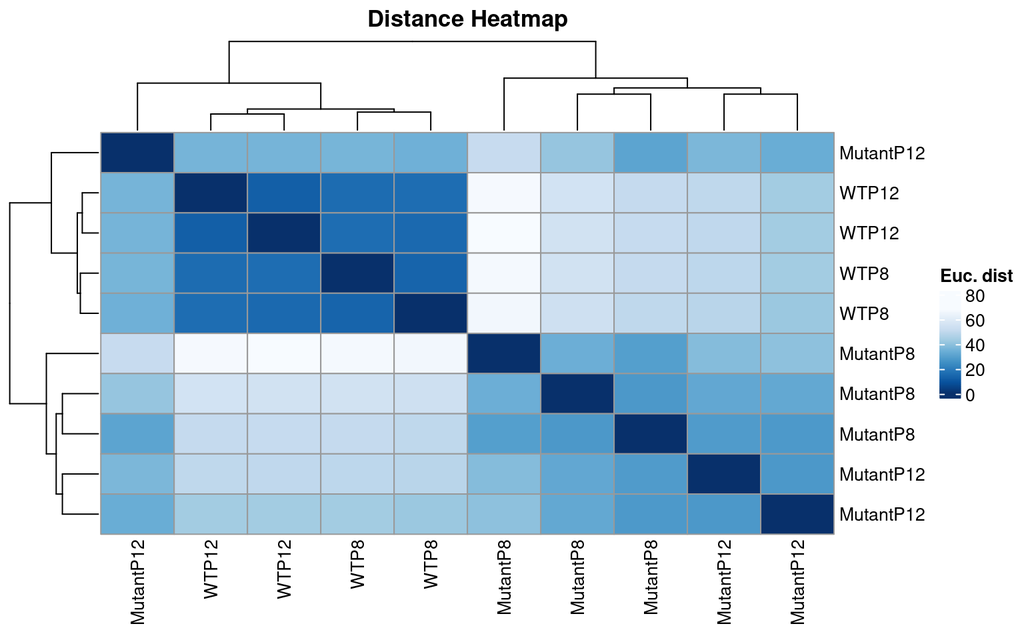

```r
#-------------------------- VST Transformation --------------------------#
ddsWTvsMut = DESeq(ddsWTvsMut) # WT vs Mutant
vsd = varianceStabilizingTransformation(ddsWTvsMut, blind = FALSE) # Transformation of the normalized counts in order to create at heatmap and PCA plot

#-------------------------- Distance Heatmap --------------------------#
data = t(assay(vsd)) # Extraction of the transformed counts
sampleDists = dist(data)
sampleDistMatrix = as.matrix(sampleDists)
rownames(sampleDistMatrix) = vsd$Genotype_Passage
colnames(sampleDistMatrix) = vsd$Genotype_Passage
colors = colorRampPalette(rev(brewer.pal(9, "Blues")))(255)
hm = pheatmap(sampleDistMatrix,
              name = "Euc. dist",
              clustering_distance_rows = sampleDists,
              clustering_distance_cols = sampleDists,
              col = colors,
              main = "Distance Heatmap",
              silent = TRUE)

#-------------------------- PCA Plot --------------------------#
data2 = as.data.frame(cbind(data, colData(vsd))) # Data table with the samples information the plot
pca_res = prcomp(data)
PCA = autoplot(pca_res, data = data2, col = "Genotype", shape = "Passage",label.size = 3)+
  ggtitle("PCA Plot")

hm
```

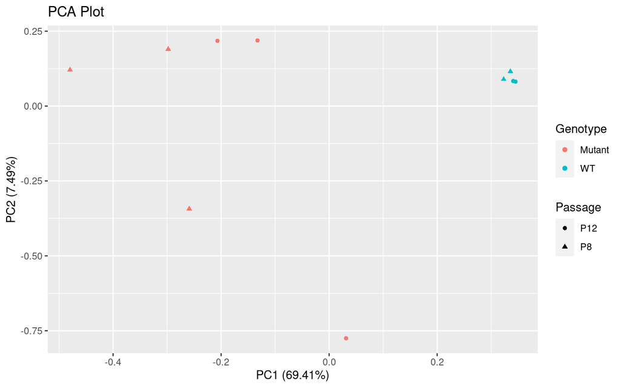

```r
PCA
```

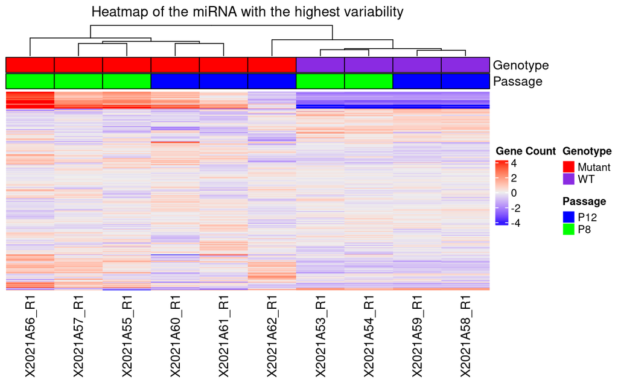

```r
topVarGenes = head(order(rowVars(assay(vsd)), decreasing = TRUE),n = 2000) # Without batch effect
hmap_data = (assay(vsd))[topVarGenes,]
hmap_data  <- hmap_data - rowMeans(hmap_data)
ha = HeatmapAnnotation(Genotype = colData(vsd)[,1],
                       Passage = colData(vsd)[,2],
                       col = list(Genotype = c("WT" = "blueviolet","Mutant" = "red"),
                                  Passage = c("P8" = "green","P12" = "blue")),
                       gp = gpar(col = "black"))
Heatmap(hmap_data, name = "Gene Count",show_row_names = FALSE,show_row_dend = FALSE ,top_annotation = ha, column_title = "Heatmap of the miRNA with the highest variability")
```

# 5 Differential expression analysis using DESeq2 : wt vs mutant VSMCs

As said previously, we first want to know **what miRNAs are differential expressed in mutant VSMCs compared to WT VSMCs**. Differential expression analysis tests the hypothesis using a count table (with raw counts, our miRNAs count matrix). We look for genes for which the count changes between two conditions more significantly than expected by chance. Statistical thresholds are used to decide if the difference between counts is significant. We made our analysis with `DESeq2`, an R package. It is available in [Bioconductor](https://bioconductor.org/packages/release/bioc/html/DESeq2.html). The `DESeq2` package is designed for normalization, visualization and differential analysis of high-dimensional count data.

```r
x = list(c("Mutant","WT"))
WTvsMutRes = ddsRes (ddsWTvsMut,"Genotype",x, alpha, nameOutput, lfc_threshold, dir)
```

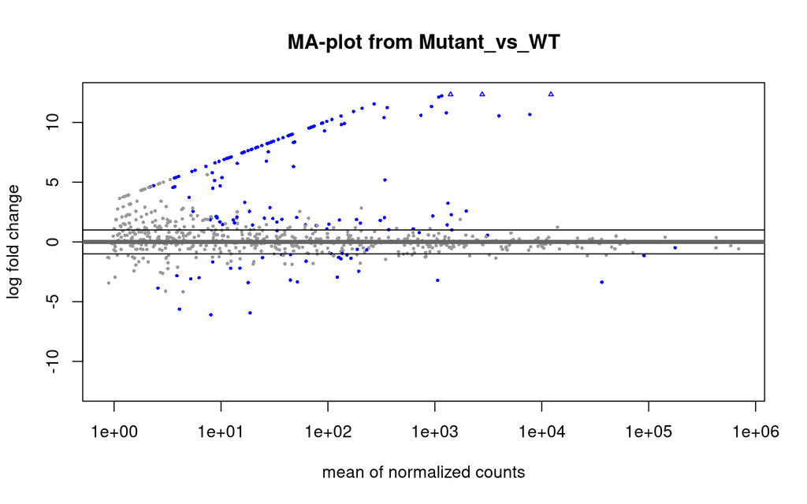

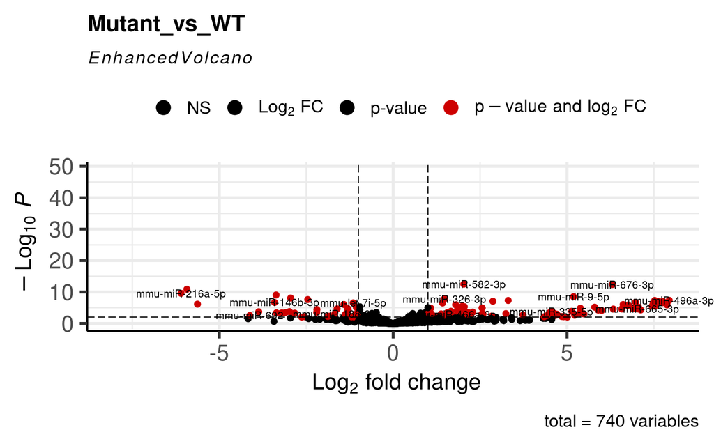

```r
names(WTvsMutRes) = sapply(list(c("Mutant","WT")), function(c){paste(c[1], "_vs_", c[2], sep = "")})
```

The following table summarizes the number of DEmiR : total, down- and up- regulated ones. As said previously the genes are selected according to their adjusted pvalue (adjusted) < 0.01 and abs(l2fc) > 1.

```r
WTvsMutRes_sig = sign(WTvsMutRes,log2FCUP,log2FCDOWN,alpha)
WTvsMutRes_sig = WTvsMutRes_sig[[1]]
nDEG = data.frame(DEG = nrow(WTvsMutRes_sig),
       DOWN = nrow(WTvsMutRes_sig[WTvsMutRes_sig$log2FoldChange < log2FCDOWN,]),
       UP = nrow(WTvsMutRes_sig[WTvsMutRes_sig$log2FoldChange > log2FCUP,]),
       row.names = "Mutant vs WT")
nDEG
```

|  | DEG | DOWN | UP |
| --- | --- | --- | --- |
| Mutant vs WT | 148 | 27 | 121 |

## 5.1 Visualisation of the DEmiR

Here are the result of the differential analysis. This table contains the `baseMean`, `log2FoldChange`, `lfcSE`, `stat`, `pvalue`, `padj` of each tested miRNA. You have the possibility to apply different thresholds in the table, and search for the results of a specific gene. Note that for the next parts I will consider the significant DEG according to the filter we defined previously : padj < 0.01 and abs(l2fc) > 1.

```r
datatable(as.data.frame(WTvsMutRes$Mutant_vs_WT),filter = 'top', caption = paste('Differential gene expression analysis -', "Mutant vs WT"))
```

|  | baseMean | log2FoldChange | lfcSE | stat | pvalue | padj |
| --- | --- | --- | --- | --- | --- | --- |
| mmu-miR-127-3p | 12187.2278281702 | 12.5222798790999 | 0.893960931417524 | 14.0076366192465 | 1.39986406732274e-44 | 8.88913682749943e-42 |
| mmu-miR-411-5p | 7733.50041838821 | 10.6666827454405 | 0.922563339397605 | 11.5620058698684 | 6.41915659296765e-31 | 2.03808221826723e-28 |
| mmu-miR-541-5p | 3977.55741282027 | 10.5557054077334 | 0.98642824902774 | 10.7009358441808 | 1.00755434504483e-26 | 2.13265669701155e-24 |
| mmu-miR-434-3p | 2771.76613138655 | 12.8800759569275 | 1.25480598357368 | 10.2645955833309 | 1.01746394669523e-24 | 1.61522401537869e-22 |
| mmu-miR-410-3p | 1403.22280927533 | 12.4663611419708 | 1.34586362410708 | 9.2627224026815 | 1.9928497126842e-20 | 2.53091913510893e-18 |
| mmu-miR-434-5p | 930.794328849294 | 11.334079352305 | 1.23147373232182 | 9.20367122320642 | 3.45924519724306e-20 | 3.66103450041557e-18 |
| mmu-miR-381-3p | 1281.08289521285 | 10.8011174721956 | 1.18378113987893 | 9.12425203302387 | 7.22333139375973e-20 | 6.5525934786249e-18 |
| mmu-miR-136-5p | 270.560866468386 | 11.5573306266686 | 1.30080521526503 | 8.88475114570775 | 6.40640085301854e-19 | 5.08508067708346e-17 |
| mmu-miR-409-3p | 741.583365801064 | 10.5985935657153 | 1.19783034288616 | 8.84815919771916 | 8.89746697767706e-19 | 6.27765725647215e-17 |
| mmu-miR-136-3p | 1156.24298086342 | 12.2245324703166 | 1.4005736355196 | 8.72823260433671 | 2.58683204688854e-18 | 1.64263834977422e-16 |

[output cut: 730 more lines]

# 6 Differential expression analysis using DESeq2 : wt vs mutant VSMCs at different passages

Now we’ll compare the miRNAs expression profiles of the mutant cells against the wt cells considering the different passages. The passage can be assimilated to the age of the cells, so the analysis will allows us to know **what miRNAs are differential expressed in mutant VSMCs compared to WT VSMCs and if the difference in “age” induces any additional changes**.

The process is exactly the same, but when doing the differential analysis with DESeq2 we include the genotype and the passage.

```r
ddsAllCond = DESeqDataSetFromMatrix(countData = count,
                              colData = coldata,
                              design = ~ Genotype_Passage)
ddsAllCond = ddsAllCond[keep,]
```

The following plots represent the results of the different analysis.

```r
ddsAllCond = DESeq(ddsAllCond) # WT vs Mutant

contrasts = list(c("MutantP12","MutantP8"),c("MutantP8","WTP8"),
                  c("WTP12","WTP8"),c("MutantP12","WTP8"))

AllCondRes = ddsRes (ddsAllCond,"Genotype_Passage",contrasts, alpha, nameOutput, lfc_threshold,dir)
```

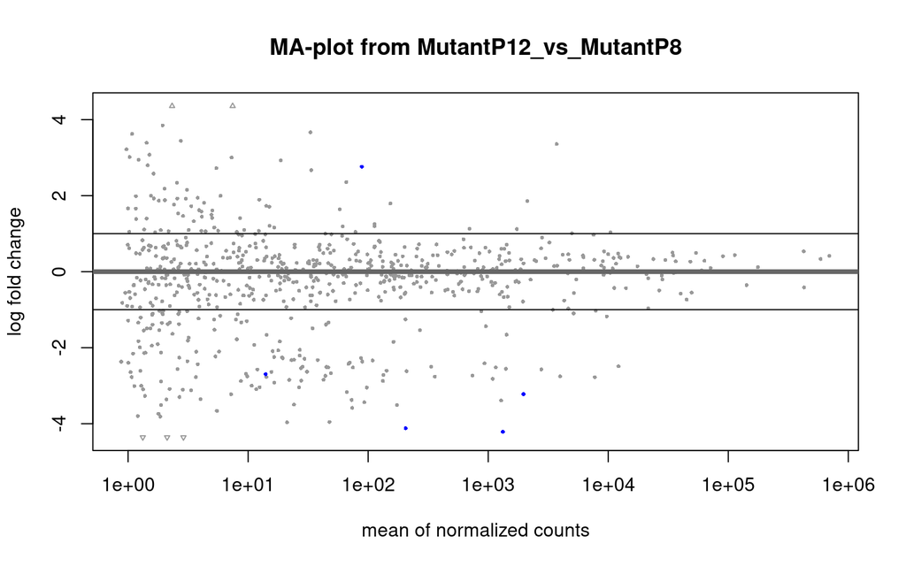

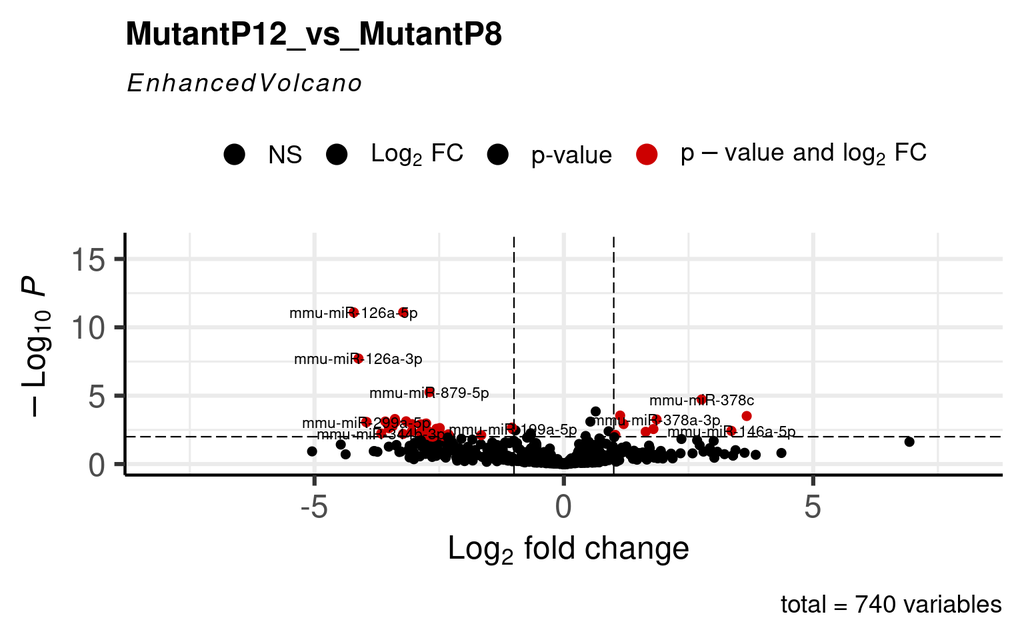

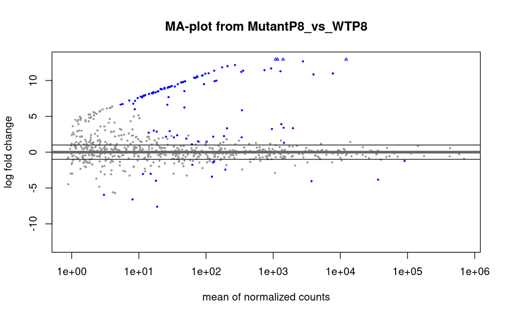

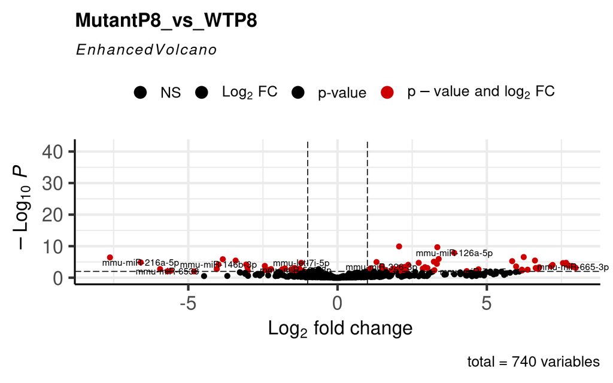

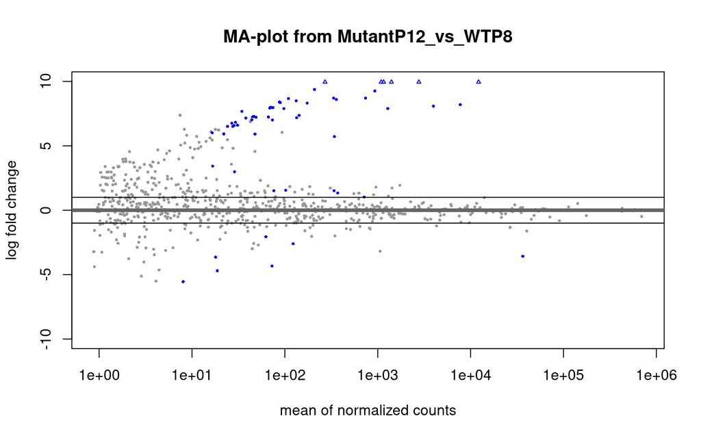

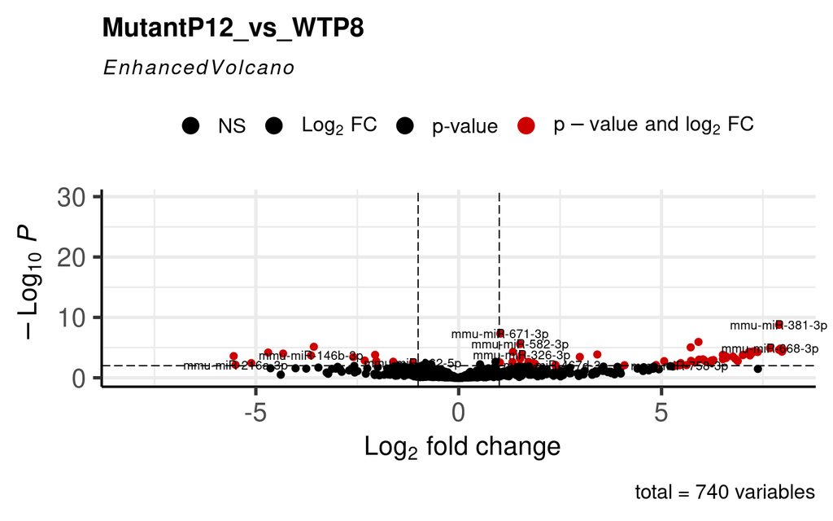

```r
names(AllCondRes) = sapply(contrasts, function(c){paste(c[1], "_vs_", c[2], sep = "")})
```

The following table sumarize the number of DEmiR in each analysis, with the same filter as before : adjusted pvalue < 0.01 and abs(l2fc) > 1.

```r
AllCondRes_sig = sign(AllCondRes,log2FCUP,log2FCDOWN,alpha)
names(AllCondRes_sig) = names(AllCondRes)
res = AllCondRes_sig

UP = sapply(X = names(res),function(name, log2FCUP,alpha, res){
  UP = nrow(res[[name]][res[[name]]$log2FoldChange > log2FCUP & res[[name]]$padj < alpha & !is.na(res[[name]]$padj),])
  }, log2FCUP, alpha, res)

DOWN = sapply(X = names(res),function(name, log2FCDOWN,alpha, res){
  DOWN = nrow(res[[name]][res[[name]]$log2FoldChange < log2FCDOWN & res[[name]]$padj < alpha & !is.na(res[[name]]$padj),])
  },  log2FCDOWN,alpha, res)

nDEG = data.frame(DE = sapply(AllCondRes_sig, nrow),
       DOWN = DOWN,
       UP = UP,
       row.names = names(AllCondRes_sig))
nDEG
```

|  | DE | DOWN | UP |
| --- | --- | --- | --- |
| MutantP12_vs_MutantP8 | 5 | 4 | 1 |
| MutantP8_vs_WTP8 | 105 | 14 | 91 |
| WTP12_vs_WTP8 | 0 | 0 | 0 |
| MutantP12_vs_WTP8 | 57 | 7 | 50 |

## 6.1 Visualisation of the DEmiR in each analysis

```r
test = names(AllCondRes_sig)
datatable(as.data.frame(AllCondRes_sig[[1]]),filter = 'top', caption = paste('Differential gene expression analysis -', test[1]))
```

|  | baseMean | log2FoldChange | lfcSE | stat | pvalue | padj |
| --- | --- | --- | --- | --- | --- | --- |
| mmu-miR-378c | 88.4647811019994 | 2.76181571018794 | 0.645635747112133 | 4.27766851903923 | 1.88860973956828e-05 | 0.00277625631716538 |
| mmu-miR-126a-5p | 1325.19310778149 | -4.21268628512504 | 0.616186876458511 | -6.83670238051344 | 8.1036849590033e-12 | 2.97810422243371e-09 |
| mmu-miR-10b-5p | 1969.67123530112 | -3.22195039086915 | 0.470873356858098 | -6.84249882466829 | 7.78235442204219e-12 | 2.97810422243371e-09 |
| mmu-miR-126a-3p | 205.264032618139 | -4.11828561341229 | 0.732912900541817 | -5.6190655265691 | 1.91993036294766e-08 | 4.70382938922176e-06 |
| mmu-miR-879-5p | 13.989414537469 | -2.69593486762947 | 0.593070284503542 | -4.54572575641053 | 5.47462815044092e-06 | 0.00100596292264352 |

```r
datatable(as.data.frame(AllCondRes_sig[[2]]),filter = 'top', caption = paste('Differential gene expression analysis -', test[2]))
```

|  | baseMean | log2FoldChange | lfcSE | stat | pvalue | padj |
| --- | --- | --- | --- | --- | --- | --- |
| mmu-miR-127-3p | 12187.2278281702 | 13.3928335564517 | 1.04635102733945 | 12.7995607654781 | 1.64881172219209e-37 | 9.51364363704836e-35 |
| mmu-miR-411-5p | 7733.50041838821 | 10.9740607402299 | 0.990118189534611 | 11.0835866427099 | 1.50711702809658e-28 | 4.34803262605864e-26 |
| mmu-miR-434-3p | 2771.76613138655 | 12.6675187695749 | 1.2915676700808 | 9.80786300479509 | 1.04150787299162e-22 | 2.00316680905387e-20 |
| mmu-miR-541-5p | 3977.55741282027 | 10.8371055447364 | 1.11369469433515 | 9.73076876441972 | 2.22901930012616e-22 | 3.21536034043198e-20 |
| mmu-miR-381-3p | 1281.08289521285 | 11.2821695992238 | 1.31014104678587 | 8.61141602036057 | 7.21635941572211e-18 | 8.32767876574332e-16 |
| mmu-miR-136-3p | 1156.24298086342 | 14.4435801340991 | 1.79168254107348 | 8.06146167247088 | 7.5387531429677e-16 | 6.43315363431096e-14 |
| mmu-miR-434-5p | 930.794328849294 | 11.6724682859116 | 1.44869562937288 | 8.05722613449478 | 7.80451914041191e-16 | 6.43315363431096e-14 |
| mmu-miR-410-3p | 1403.22280927533 | 13.2736703870392 | 1.69977561146334 | 7.80907214900668 | 5.76105161838072e-15 | 4.15515847975709e-13 |
| mmu-miR-409-3p | 741.583365801064 | 11.4362453678834 | 1.47575134199719 | 7.74943924659168 | 9.22992259201941e-15 | 5.91740592843911e-13 |
| mmu-miR-300-3p | 1089.68260886845 | 12.9701936087401 | 1.77289746503288 | 7.3158171098742 | 2.55819889428471e-13 | 1.47608076200228e-11 |

[output cut: 95 more lines]

```r
datatable(as.data.frame(AllCondRes_sig[[3]]),filter = 'top', caption = paste('Differential gene expression analysis -', test[3]))
```

|  | baseMean | log2FoldChange | lfcSE | stat | pvalue | padj |
| --- | --- | --- | --- | --- | --- | --- |

```r
datatable(as.data.frame(AllCondRes_sig[[4]]),filter = 'top', caption = paste('Differential gene expression analysis -', test[4]))
```

|  | baseMean | log2FoldChange | lfcSE | stat | pvalue | padj |
| --- | --- | --- | --- | --- | --- | --- |
| mmu-miR-127-3p | 12187.2278281702 | 10.9042661439583 | 1.04640231270324 | 10.4207206077256 | 1.99436343572854e-25 | 1.12282661431517e-22 |
| mmu-miR-411-5p | 7733.50041838821 | 8.19842940546037 | 0.990224070962346 | 8.27936791871031 | 1.23830795994701e-16 | 3.48583690725083e-14 |
| mmu-miR-434-3p | 2771.76613138655 | 10.0961050928144 | 1.29176357035369 | 7.81575307163223 | 5.46353877715056e-15 | 1.02532411051192e-12 |
| mmu-miR-541-5p | 3977.55741282027 | 8.08269791197331 | 1.11387524062274 | 7.25637631325255 | 3.97597960611932e-13 | 5.59619129561295e-11 |
| mmu-miR-136-3p | 1156.24298086342 | 11.9251661728726 | 1.79200847592217 | 6.65463714770429 | 2.83999822244347e-11 | 3.19783799847134e-09 |
| mmu-miR-434-5p | 930.794328849294 | 9.2615579605252 | 1.44915974936165 | 6.39098482041397 | 1.64820745555343e-10 | 1.5465679957943e-08 |
| mmu-miR-410-3p | 1403.22280927533 | 10.718185573989 | 1.70006666093224 | 6.30456782683546 | 2.8899914581144e-10 | 2.32437884416915e-08 |
| mmu-miR-136-5p | 270.560866468386 | 10.6175559459656 | 1.75595508830823 | 6.04659880919564 | 1.47935519600068e-09 | 1.04109621918548e-07 |
| mmu-miR-381-3p | 1281.08289521285 | 7.89432475956169 | 1.31089011711748 | 6.0221102108242 | 1.72157598024714e-09 | 1.0769414187546e-07 |
| mmu-miR-409-3p | 741.583365801064 | 8.70304169810044 | 1.47647419336993 | 5.89447600044837 | 3.75872219453916e-09 | 2.11616059552554e-07 |

[output cut: 47 more lines]

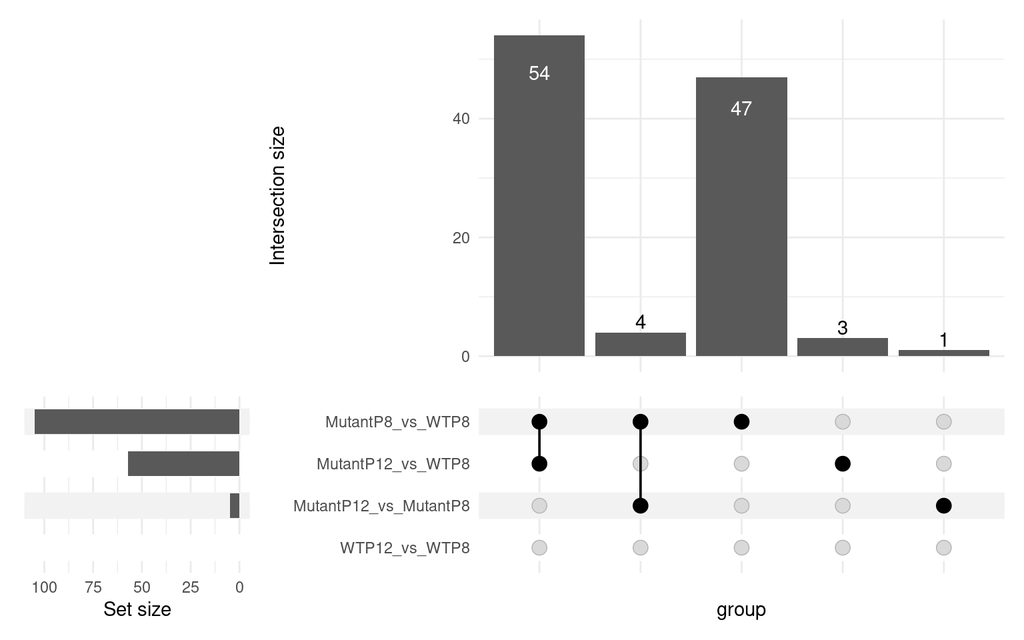

```r
all_deg = lapply (AllCondRes_sig,rownames)
all_deg = as.data.frame(as.matrix(list_to_matrix(all_deg)))
upset(all_deg,colnames(all_deg),sort_intersections_by=c('degree','cardinality'))
```

# 7 miRNA targets

Using the miTarBAse database I identified the target of the differentially expressed miRNA (identified in the condition mutant vs wild type), among the previously identified DEGs. The first table sumurize this information. The second table is filtered for miRNA and mRNA that had high weight for the factor 1 in the MOFA analysis.

```r
mRNA_wt_vs_mut = read.csv("~/Documents/2.Omics_analysis/1.2021_Progeria/2.mRNA_Analysis/DEG Results/Sign/2021Progeria_Mutant_vs_WT_alpha0.01_SIGN.csv", header = TRUE, sep = ";", row.names = 1)
miRTarBase = read.csv(paste(dir,"miRTarBase_SE_WR.csv",sep=""), header = TRUE, sep = ";")
#miRTarBase = dplyr::filter(miRTarBase, endsWith(miRTarBase$Support.Type, "(Weak)") == FALSE)
miRTarBase = dplyr::filter(miRTarBase, Species..Target.Gene. == "Mus musculus")
genes = rownames(mRNA_wt_vs_mut)
geneIDs = ensembldb::select(EnsDb.Mmusculus.v75, keys= genes, keytype = "GENEID", columns = c("SYMBOL","GENEID"))
miRNA_mRNA_pred_target = dplyr::filter(miRTarBase, Target.Gene %in% geneIDs$SYMBOL)
miRNA_mRNA_pred_target = dplyr::filter(miRNA_mRNA_pred_target, miRNA %in% rownames(WTvsMutRes_sig))
```

```r
MOFAobject = load_model("MOFA2.hdf5")
wmRNA = get_weights(MOFAobject, views = "mRNA", factors = 1, as.data.frame = T)
abswm = sapply(wmRNA$value, abs)
wmRNA = dplyr::filter(wmRNA, value > max(abswm)/8)
wmiRNA = get_weights(MOFAobject, views = "miRNA", factors = 1, as.data.frame = T)
abswmi = sapply(wmiRNA$value, abs)
wmiRNA = dplyr::filter(wmiRNA, value > max(abswmi)/10)
```

```r
miRNA_mRNA_pred_target_corMOFA = dplyr::filter(miRNA_mRNA_pred_target, miRNA %in% wmiRNA$feature)
mRNAs = tolower(wmRNA$feature)
mRNAs = str_to_title(mRNAs)
miRNA_mRNA_pred_target_corMOFA = dplyr::filter(miRNA_mRNA_pred_target_corMOFA, Target.Gene %in% mRNAs)
```

```r
write.table(x = miRNA_mRNA_pred_target_corMOFA,
                file = paste(dir, "RNA_targ_MOFA.csv", sep = ""),
                quote = FALSE, sep = ";", row.names = TRUE, col.names = NA)

write.table(x = miRNA_mRNA_pred_target,
                file = paste(dir, "RNA_targ.csv", sep = ""),
                quote = FALSE, sep = ";", row.names = TRUE, col.names = NA)
```

```r
miRNA_mRNA_pred_target
```

| miRTarBase.ID | miRNA | Species..miRNA. | Target.Gene | Target.Gene..Entrez.ID. | Species..Target.Gene. | Experiments | Support.Type | References..PMID. |
| --- | --- | --- | --- | --- | --- | --- | --- | --- |
| MIRT001913 | mmu-miR-9-5p | Mus musculus | Foxg1 | 15228 | Mus musculus | Luciferase reporter assay | Functional MTI | 18842901 |
| MIRT002868 | mmu-miR-206-3p | Mus musculus | Mmd | 67468 | Mus musculus | Luciferase reporter assay//Microarray | Functional MTI | 16923828 |
| MIRT002878 | mmu-miR-206-3p | Mus musculus | Fstl1 | 14314 | Mus musculus | Luciferase reporter assay//Northern blot//qRT-PCR | Functional MTI | 17030984 |
| MIRT003283 | mmu-miR-497a-5p | Mus musculus | Bcl2 | 12043 | Mus musculus | Luciferase reporter assay//Western blot | Functional MTI | 20053374 |
| MIRT003374 | mmu-miR-195a-5p | Mus musculus | Arl2 | 56327 | Mus musculus | Luciferase reporter assay//qRT-PCR//Western blot | Functional MTI | 20007690 |
| MIRT004014 | mmu-miR-206-3p | Mus musculus | Spry1 | 24063 | Mus musculus | Luciferase reporter assay | Non-Functional MTI | 19043405 |
| MIRT004038 | mmu-miR-195a-5p | Mus musculus | Ccnd1 | 12443 | Mus musculus | Immunohistochemistry//Luciferase reporter assay//Northern blot//qRT-PCR//Western blot | Functional MTI | 19441017 |
| MIRT004717 | mmu-miR-134-5p | Mus musculus | Limk1 | 16885 | Mus musculus | Immunohistochemistry//Luciferase reporter assay//Western blot | Functional MTI | 20126250 |
| MIRT005079 | mmu-miR-124-3p | Mus musculus | Jag1 | 16449 | Mus musculus | Luciferase reporter assay | Functional MTI | 19287386 |
| MIRT005081 | mmu-miR-124-3p | Mus musculus | Sox9 | 20682 | Mus musculus | Luciferase reporter assay | Functional MTI | 19287386 |

[output cut: 64 more lines]

```r
miRNA_mRNA_pred_target_corMOFA
```

| miRTarBase.ID | miRNA | Species..miRNA. | Target.Gene | Target.Gene..Entrez.ID. | Species..Target.Gene. | Experiments | Support.Type | References..PMID. |
| --- | --- | --- | --- | --- | --- | --- | --- | --- |
| MIRT001913 | mmu-miR-9-5p | Mus musculus | Foxg1 | 15228 | Mus musculus | Luciferase reporter assay | Functional MTI | 18842901 |
| MIRT004717 | mmu-miR-134-5p | Mus musculus | Limk1 | 16885 | Mus musculus | Immunohistochemistry//Luciferase reporter assay//Western blot | Functional MTI | 20126250 |
| MIRT005945 | mmu-miR-200b-3p | Mus musculus | Flt1 | 14254 | Mus musculus | Luciferase reporter assay | Functional MTI | 21115742 |
| MIRT005948 | mmu-miR-429-3p | Mus musculus | Flt1 | 14254 | Mus musculus | Luciferase reporter assay | Non-Functional MTI | 21115742 |
| MIRT053314 | mmu-miR-204-5p | Mus musculus | Bcl2 | 12043 | Mus musculus | Luciferase reporter assay//qRT-PCR//Western blot | Functional MTI | 22892391 |
| MIRT438150 | mmu-miR-126a-5p | Mus musculus | Alcam | 11658 | Mus musculus | Luciferase reporter assay//qRT-PCR | Functional MTI | 24562769 |
| MIRT732664 | mmu-miR-154-5p | Mus musculus | Wnt11 | 22411 | Mus musculus | Microarray//Luciferase reporter assay//qRT-PCR//Western blot | Functional MTI | 25959411 |
| MIRT734717 | mmu-miR-429-3p | Mus musculus | Bcl2 | 12043 | Mus musculus | Luciferase reporter assay | Functional MTI | 26489013 |
| MIRT734719 | mmu-miR-329-3p | Mus musculus | Dlk1 | 13386 | Mus musculus | Luciferase reporter assay//Western blot | Functional MTI | 26487685 |
| MIRT001913 | mmu-miR-9-5p | Mus musculus | Foxg1 | 15228 | Mus musculus | Luciferase reporter assay//Other |  | 18842901 |

[output cut: 6 more lines]